# Risk Factor Analysis

## Outcome Variable

**Outcome Variable:** whz

## Predictor Variables

**Intervention Variable:** predfeed3

**Adjustment Set:**

- arm
- sex
- month
- brthmon
- W_mage
- meducyrs
- feducyrs
- hhwealth_quart
- hfoodsec
- W_mhtcm
- vagbrth
- W_gagebrth
- W_birthwt
- W_birthlen
- W_nrooms
- W_nchldlt5
- W_parity
- impfloor
- impsan
- safeh20
- delta_W_mage
- delta_meducyrs
- delta_feducyrs
- delta_hhwealth_quart
- delta_hfoodsec
- delta_W_mhtcm
- delta_vagbrth
- delta_W_gagebrth
- delta_W_birthwt
- delta_W_birthlen
- delta_W_nrooms
- delta_W_nchldlt5
- delta_W_parity
- delta_impfloor
- delta_impsan
- delta_safeh20

## Stratifying Variables

The analysis was stratified on these variable(s):

- agecat
- studyid
- country

## Data Summary

| agecat | studyid | country | predfeed3 | n_cell | n |
| --- | --- | --- | --- | --- | --- |
| Birth | ki0047075b-MAL-ED | BANGLADESH | 1 | 193 | 227 |
| Birth | ki0047075b-MAL-ED | BANGLADESH | 0 | 34 | 227 |
| Birth | ki0047075b-MAL-ED | BRAZIL | 1 | 97 | 177 |
| Birth | ki0047075b-MAL-ED | BRAZIL | 0 | 80 | 177 |
| Birth | ki0047075b-MAL-ED | INDIA | 1 | 150 | 193 |
| Birth | ki0047075b-MAL-ED | INDIA | 0 | 43 | 193 |
| Birth | ki0047075b-MAL-ED | NEPAL | 1 | 97 | 166 |
| Birth | ki0047075b-MAL-ED | NEPAL | 0 | 69 | 166 |
| Birth | ki0047075b-MAL-ED | PERU | 1 | 177 | 265 |
| Birth | ki0047075b-MAL-ED | PERU | 0 | 88 | 265 |
| Birth | ki0047075b-MAL-ED | SOUTH AFRICA | 1 | 87 | 231 |
| Birth | ki0047075b-MAL-ED | SOUTH AFRICA | 0 | 144 | 231 |
| Birth | ki0047075b-MAL-ED | TANZANIA, UNITED REPUBLIC OF | 1 | 49 | 114 |
| Birth | ki0047075b-MAL-ED | TANZANIA, UNITED REPUBLIC OF | 0 | 65 | 114 |
| Birth | ki1000109-EE | PAKISTAN | 1 | 1 | 1 |
| Birth | ki1000109-EE | PAKISTAN | 0 | 0 | 1 |
| Birth | kiGH5241-JiVitA-3 | BANGLADESH | 1 | 13739 | 15136 |
| Birth | kiGH5241-JiVitA-3 | BANGLADESH | 0 | 1397 | 15136 |
| Birth | kiGH5241-JiVitA-4 | BANGLADESH | 1 | 28 | 31 |
| Birth | kiGH5241-JiVitA-4 | BANGLADESH | 0 | 3 | 31 |
| 6 months | ki0047075b-MAL-ED | BANGLADESH | 1 | 203 | 237 |
| 6 months | ki0047075b-MAL-ED | BANGLADESH | 0 | 34 | 237 |
| 6 months | ki0047075b-MAL-ED | BRAZIL | 1 | 116 | 209 |
| 6 months | ki0047075b-MAL-ED | BRAZIL | 0 | 93 | 209 |
| 6 months | ki0047075b-MAL-ED | INDIA | 1 | 178 | 233 |
| 6 months | ki0047075b-MAL-ED | INDIA | 0 | 55 | 233 |
| 6 months | ki0047075b-MAL-ED | NEPAL | 1 | 132 | 233 |
| 6 months | ki0047075b-MAL-ED | NEPAL | 0 | 101 | 233 |
| 6 months | ki0047075b-MAL-ED | PERU | 1 | 183 | 270 |
| 6 months | ki0047075b-MAL-ED | PERU | 0 | 87 | 270 |
| 6 months | ki0047075b-MAL-ED | SOUTH AFRICA | 1 | 86 | 248 |
| 6 months | ki0047075b-MAL-ED | SOUTH AFRICA | 0 | 162 | 248 |
| 6 months | ki0047075b-MAL-ED | TANZANIA, UNITED REPUBLIC OF | 1 | 91 | 240 |
| 6 months | ki0047075b-MAL-ED | TANZANIA, UNITED REPUBLIC OF | 0 | 149 | 240 |
| 6 months | ki1000109-EE | PAKISTAN | 1 | 349 | 375 |
| 6 months | ki1000109-EE | PAKISTAN | 0 | 26 | 375 |
| 6 months | ki1113344-GMS-Nepal | NEPAL | 1 | 379 | 458 |
| 6 months | ki1113344-GMS-Nepal | NEPAL | 0 | 79 | 458 |
| 6 months | kiGH5241-JiVitA-3 | BANGLADESH | 1 | 14763 | 16253 |
| 6 months | kiGH5241-JiVitA-3 | BANGLADESH | 0 | 1490 | 16253 |
| 6 months | kiGH5241-JiVitA-4 | BANGLADESH | 1 | 77 | 89 |
| 6 months | kiGH5241-JiVitA-4 | BANGLADESH | 0 | 12 | 89 |
| 24 months | ki0047075b-MAL-ED | BANGLADESH | 1 | 178 | 208 |
| 24 months | ki0047075b-MAL-ED | BANGLADESH | 0 | 30 | 208 |
| 24 months | ki0047075b-MAL-ED | BRAZIL | 1 | 98 | 169 |
| 24 months | ki0047075b-MAL-ED | BRAZIL | 0 | 71 | 169 |
| 24 months | ki0047075b-MAL-ED | INDIA | 1 | 170 | 225 |
| 24 months | ki0047075b-MAL-ED | INDIA | 0 | 55 | 225 |
| 24 months | ki0047075b-MAL-ED | NEPAL | 1 | 128 | 225 |
| 24 months | ki0047075b-MAL-ED | NEPAL | 0 | 97 | 225 |
| 24 months | ki0047075b-MAL-ED | PERU | 1 | 137 | 199 |
| 24 months | ki0047075b-MAL-ED | PERU | 0 | 62 | 199 |
| 24 months | ki0047075b-MAL-ED | SOUTH AFRICA | 1 | 81 | 232 |
| 24 months | ki0047075b-MAL-ED | SOUTH AFRICA | 0 | 151 | 232 |
| 24 months | ki0047075b-MAL-ED | TANZANIA, UNITED REPUBLIC OF | 1 | 79 | 210 |
| 24 months | ki0047075b-MAL-ED | TANZANIA, UNITED REPUBLIC OF | 0 | 131 | 210 |
| 24 months | ki1113344-GMS-Nepal | NEPAL | 1 | 336 | 404 |
| 24 months | ki1113344-GMS-Nepal | NEPAL | 0 | 68 | 404 |
| 24 months | kiGH5241-JiVitA-3 | BANGLADESH | 1 | 7495 | 8313 |
| 24 months | kiGH5241-JiVitA-3 | BANGLADESH | 0 | 818 | 8313 |
| 24 months | kiGH5241-JiVitA-4 | BANGLADESH | 1 | 136 | 151 |
| 24 months | kiGH5241-JiVitA-4 | BANGLADESH | 0 | 15 | 151 |

The following strata were considered:

- agecat: 24 months, studyid: ki0047075b-MAL-ED, country: BANGLADESH
- agecat: 24 months, studyid: ki0047075b-MAL-ED, country: BRAZIL
- agecat: 24 months, studyid: ki0047075b-MAL-ED, country: INDIA
- agecat: 24 months, studyid: ki0047075b-MAL-ED, country: NEPAL
- agecat: 24 months, studyid: ki0047075b-MAL-ED, country: PERU
- agecat: 24 months, studyid: ki0047075b-MAL-ED, country: SOUTH AFRICA
- agecat: 24 months, studyid: ki0047075b-MAL-ED, country: TANZANIA, UNITED REPUBLIC OF
- agecat: 24 months, studyid: ki1113344-GMS-Nepal, country: NEPAL
- agecat: 24 months, studyid: kiGH5241-JiVitA-3, country: BANGLADESH
- agecat: 24 months, studyid: kiGH5241-JiVitA-4, country: BANGLADESH
- agecat: 6 months, studyid: ki0047075b-MAL-ED, country: BANGLADESH
- agecat: 6 months, studyid: ki0047075b-MAL-ED, country: BRAZIL
- agecat: 6 months, studyid: ki0047075b-MAL-ED, country: INDIA
- agecat: 6 months, studyid: ki0047075b-MAL-ED, country: NEPAL
- agecat: 6 months, studyid: ki0047075b-MAL-ED, country: PERU
- agecat: 6 months, studyid: ki0047075b-MAL-ED, country: SOUTH AFRICA
- agecat: 6 months, studyid: ki0047075b-MAL-ED, country: TANZANIA, UNITED REPUBLIC OF
- agecat: 6 months, studyid: ki1000109-EE, country: PAKISTAN
- agecat: 6 months, studyid: ki1113344-GMS-Nepal, country: NEPAL
- agecat: 6 months, studyid: kiGH5241-JiVitA-3, country: BANGLADESH
- agecat: 6 months, studyid: kiGH5241-JiVitA-4, country: BANGLADESH
- agecat: Birth, studyid: ki0047075b-MAL-ED, country: BANGLADESH
- agecat: Birth, studyid: ki0047075b-MAL-ED, country: BRAZIL
- agecat: Birth, studyid: ki0047075b-MAL-ED, country: INDIA
- agecat: Birth, studyid: ki0047075b-MAL-ED, country: NEPAL
- agecat: Birth, studyid: ki0047075b-MAL-ED, country: PERU
- agecat: Birth, studyid: ki0047075b-MAL-ED, country: SOUTH AFRICA
- agecat: Birth, studyid: ki0047075b-MAL-ED, country: TANZANIA, UNITED REPUBLIC OF
- agecat: Birth, studyid: ki1000109-EE, country: PAKISTAN
- agecat: Birth, studyid: kiGH5241-JiVitA-3, country: BANGLADESH
- agecat: Birth, studyid: kiGH5241-JiVitA-4, country: BANGLADESH

### Dropped Strata

Some strata were dropped due to rare outcomes:

- agecat: Birth, studyid: ki1000109-EE, country: PAKISTAN
- agecat: Birth, studyid: kiGH5241-JiVitA-4, country: BANGLADESH

## Methods Detail

We’re interested in the causal parameters $E[Y_a]$ for all values of $a \in \mathcal{A}$. These parameters represent the mean outcome if, possibly contrary to fact, we intervened to set all units to have $A=a$. Under the randomization and positivity assumptions, these are identified by the statistical parameters $\psi_a=E_W[E_{Y|A,W}(Y|A=a,W)]$. In addition, we’re interested in the mean of $Y$, $E[Y]$ under no intervention (the observed mean). We will estimate these parameters by using SuperLearner to fit the relevant likelihood factors – $E_{Y|A,W}(Y|A=a,W)$ and $p(A=a|W)$, and then updating our likelihood fit using a joint TMLE.

For unadjusted analyses ($W=\{\}$), initial likelihoods were estimated using Lrnr_glm to estimate the simple $E(Y|A)$ and Lrnr_mean to estimate $p(A)$. For adjusted analyses, a small library containing Lrnr_glmnet, Lrnr_xgboost, and Lrnr_mean was used.

Having estimated these parameters, we will then use the delta method to estimate relative risks and attributable risks relative to a prespecified baseline level of $A$.

# Results Detail

## Results Plots

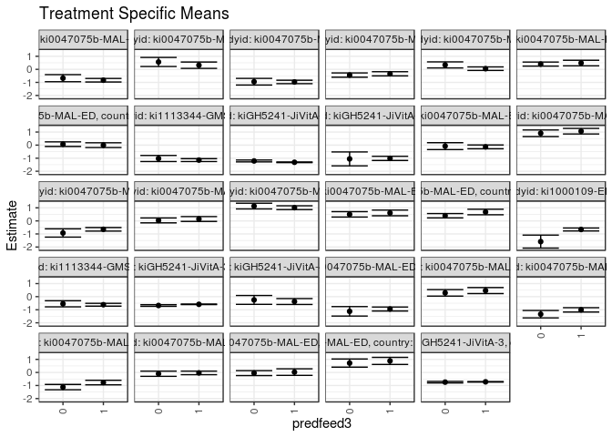

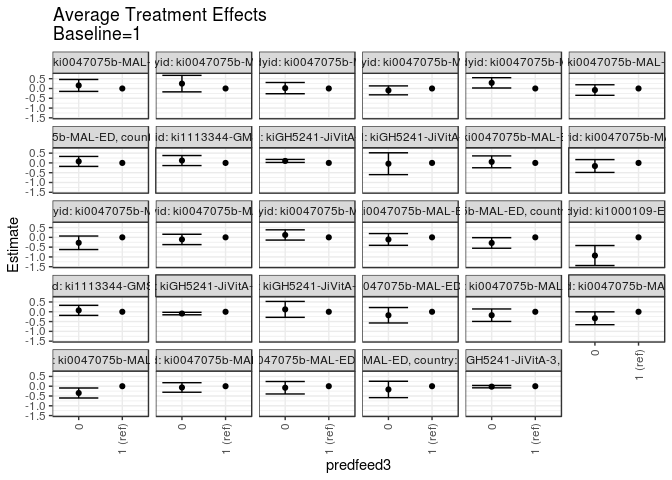

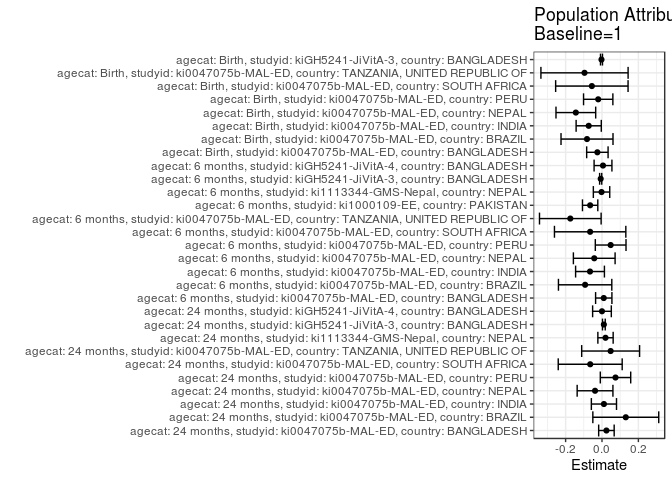

## Results Table

### Parameter: TSM

| agecat | studyid | country | intervention_level | baseline_level | estimate | ci_lower | ci_upper |
| --- | --- | --- | --- | --- | --- | --- | --- |
| Birth | ki0047075b-MAL-ED | BANGLADESH | 1 | NA | -0.9447759 | -1.0962184 | -0.7933334 |
| Birth | ki0047075b-MAL-ED | BANGLADESH | 0 | NA | -1.1225467 | -1.4853125 | -0.7597808 |
| Birth | ki0047075b-MAL-ED | BRAZIL | 1 | NA | 0.4661127 | 0.2362171 | 0.6960083 |
| Birth | ki0047075b-MAL-ED | BRAZIL | 0 | NA | 0.2911202 | 0.0426669 | 0.5395735 |
| Birth | ki0047075b-MAL-ED | INDIA | 1 | NA | -1.0093699 | -1.1759567 | -0.8427831 |
| Birth | ki0047075b-MAL-ED | INDIA | 0 | NA | -1.3398263 | -1.6221120 | -1.0575406 |
| Birth | ki0047075b-MAL-ED | NEPAL | 1 | NA | -0.7746387 | -0.9490542 | -0.6002231 |
| Birth | ki0047075b-MAL-ED | NEPAL | 0 | NA | -1.1216017 | -1.3246127 | -0.9185908 |
| Birth | ki0047075b-MAL-ED | PERU | 1 | NA | -0.0350387 | -0.1725797 | 0.1025023 |
| Birth | ki0047075b-MAL-ED | PERU | 0 | NA | -0.0988634 | -0.2988959 | 0.1011691 |
| Birth | ki0047075b-MAL-ED | SOUTH AFRICA | 1 | NA | 0.0267005 | -0.2237774 | 0.2771784 |
| Birth | ki0047075b-MAL-ED | SOUTH AFRICA | 0 | NA | -0.0509920 | -0.2401523 | 0.1381684 |
| Birth | ki0047075b-MAL-ED | TANZANIA, UNITED REPUBLIC OF | 1 | NA | 0.8827155 | 0.6118519 | 1.1535790 |
| Birth | ki0047075b-MAL-ED | TANZANIA, UNITED REPUBLIC OF | 0 | NA | 0.7169577 | 0.4056920 | 1.0282235 |
| Birth | kiGH5241-JiVitA-3 | BANGLADESH | 1 | NA | -0.7194451 | -0.7401699 | -0.6987204 |
| Birth | kiGH5241-JiVitA-3 | BANGLADESH | 0 | NA | -0.7421396 | -0.8014016 | -0.6828777 |
| 6 months | ki0047075b-MAL-ED | BANGLADESH | 1 | NA | -0.1342608 | -0.2787162 | 0.0101945 |
| 6 months | ki0047075b-MAL-ED | BANGLADESH | 0 | NA | -0.0789338 | -0.3431209 | 0.1852533 |
| 6 months | ki0047075b-MAL-ED | BRAZIL | 1 | NA | 1.0644761 | 0.8505379 | 1.2784142 |
| 6 months | ki0047075b-MAL-ED | BRAZIL | 0 | NA | 0.9058413 | 0.6543634 | 1.1573193 |
| 6 months | ki0047075b-MAL-ED | INDIA | 1 | NA | -0.6446402 | -0.7801299 | -0.5091506 |
| 6 months | ki0047075b-MAL-ED | INDIA | 0 | NA | -0.9228689 | -1.2393508 | -0.6063870 |
| 6 months | ki0047075b-MAL-ED | NEPAL | 1 | NA | 0.1436895 | -0.0404355 | 0.3278145 |
| 6 months | ki0047075b-MAL-ED | NEPAL | 0 | NA | 0.0371261 | -0.1507722 | 0.2250244 |
| 6 months | ki0047075b-MAL-ED | PERU | 1 | NA | 1.0094822 | 0.8633916 | 1.1555728 |
| 6 months | ki0047075b-MAL-ED | PERU | 0 | NA | 1.1316443 | 0.9125832 | 1.3507054 |
| 6 months | ki0047075b-MAL-ED | SOUTH AFRICA | 1 | NA | 0.6087169 | 0.3915253 | 0.8259084 |
| 6 months | ki0047075b-MAL-ED | SOUTH AFRICA | 0 | NA | 0.5012204 | 0.2947700 | 0.7076709 |
| 6 months | ki0047075b-MAL-ED | TANZANIA, UNITED REPUBLIC OF | 1 | NA | 0.6805109 | 0.4688295 | 0.8921923 |
| 6 months | ki0047075b-MAL-ED | TANZANIA, UNITED REPUBLIC OF | 0 | NA | 0.3948941 | 0.2286945 | 0.5610937 |
| 6 months | ki1000109-EE | PAKISTAN | 1 | NA | -0.6566760 | -0.7708880 | -0.5424639 |
| 6 months | ki1000109-EE | PAKISTAN | 0 | NA | -1.5855443 | -2.0833691 | -1.0877195 |
| 6 months | ki1113344-GMS-Nepal | NEPAL | 1 | NA | -0.6168830 | -0.7248351 | -0.5089310 |
| 6 months | ki1113344-GMS-Nepal | NEPAL | 0 | NA | -0.5447024 | -0.7779354 | -0.3114694 |
| 6 months | kiGH5241-JiVitA-3 | BANGLADESH | 1 | NA | -0.5858097 | -0.6065929 | -0.5650265 |
| 6 months | kiGH5241-JiVitA-3 | BANGLADESH | 0 | NA | -0.6760725 | -0.7384264 | -0.6137186 |
| 6 months | kiGH5241-JiVitA-4 | BANGLADESH | 1 | NA | -0.3712826 | -0.5971566 | -0.1454086 |
| 6 months | kiGH5241-JiVitA-4 | BANGLADESH | 0 | NA | -0.2488208 | -0.5880539 | 0.0904124 |
| 24 months | ki0047075b-MAL-ED | BANGLADESH | 1 | NA | -0.8323933 | -0.9680136 | -0.6967731 |
| 24 months | ki0047075b-MAL-ED | BANGLADESH | 0 | NA | -0.6764028 | -0.9486773 | -0.4041283 |
| 24 months | ki0047075b-MAL-ED | BRAZIL | 1 | NA | 0.3158357 | 0.0729951 | 0.5586763 |
| 24 months | ki0047075b-MAL-ED | BRAZIL | 0 | NA | 0.5645793 | 0.2184647 | 0.9106940 |
| 24 months | ki0047075b-MAL-ED | INDIA | 1 | NA | -0.9657633 | -1.0976215 | -0.8339051 |
| 24 months | ki0047075b-MAL-ED | INDIA | 0 | NA | -0.9472263 | -1.2011252 | -0.6933274 |
| 24 months | ki0047075b-MAL-ED | NEPAL | 1 | NA | -0.3413367 | -0.5003908 | -0.1822827 |
| 24 months | ki0047075b-MAL-ED | NEPAL | 0 | NA | -0.4382066 | -0.6009898 | -0.2754235 |
| 24 months | ki0047075b-MAL-ED | PERU | 1 | NA | 0.0499929 | -0.0841627 | 0.1841485 |
| 24 months | ki0047075b-MAL-ED | PERU | 0 | NA | 0.3381620 | 0.1072696 | 0.5690545 |
| 24 months | ki0047075b-MAL-ED | SOUTH AFRICA | 1 | NA | 0.4805447 | 0.2676894 | 0.6934000 |
| 24 months | ki0047075b-MAL-ED | SOUTH AFRICA | 0 | NA | 0.4013740 | 0.2474082 | 0.5553398 |
| 24 months | ki0047075b-MAL-ED | TANZANIA, UNITED REPUBLIC OF | 1 | NA | -0.0040617 | -0.1852750 | 0.1771517 |
| 24 months | ki0047075b-MAL-ED | TANZANIA, UNITED REPUBLIC OF | 0 | NA | 0.0723529 | -0.1030203 | 0.2477262 |
| 24 months | ki1113344-GMS-Nepal | NEPAL | 1 | NA | -1.1460674 | -1.2561907 | -1.0359441 |
| 24 months | ki1113344-GMS-Nepal | NEPAL | 0 | NA | -1.0243792 | -1.2551556 | -0.7936028 |
| 24 months | kiGH5241-JiVitA-3 | BANGLADESH | 1 | NA | -1.3133641 | -1.3385769 | -1.2881513 |
| 24 months | kiGH5241-JiVitA-3 | BANGLADESH | 0 | NA | -1.2125303 | -1.2856392 | -1.1394213 |
| 24 months | kiGH5241-JiVitA-4 | BANGLADESH | 1 | NA | -1.0135684 | -1.1745726 | -0.8525643 |
| 24 months | kiGH5241-JiVitA-4 | BANGLADESH | 0 | NA | -1.0538682 | -1.5855379 | -0.5221985 |

### Parameter: E(Y)

| agecat | studyid | country | intervention_level | baseline_level | estimate | ci_lower | ci_upper |
| --- | --- | --- | --- | --- | --- | --- | --- |
| Birth | ki0047075b-MAL-ED | BANGLADESH | NA | NA | -0.9701762 | -1.1093516 | -0.8310008 |
| Birth | ki0047075b-MAL-ED | BRAZIL | NA | NA | 0.3837288 | 0.2059602 | 0.5614974 |
| Birth | ki0047075b-MAL-ED | INDIA | NA | NA | -1.0824352 | -1.2259825 | -0.9388879 |
| Birth | ki0047075b-MAL-ED | NEPAL | NA | NA | -0.9184337 | -1.0582074 | -0.7786600 |
| Birth | ki0047075b-MAL-ED | PERU | NA | NA | -0.0558491 | -0.1687562 | 0.0570581 |
| Birth | ki0047075b-MAL-ED | SOUTH AFRICA | NA | NA | -0.0290476 | -0.1772448 | 0.1191495 |
| Birth | ki0047075b-MAL-ED | TANZANIA, UNITED REPUBLIC OF | NA | NA | 0.7865789 | 0.5832028 | 0.9899551 |
| Birth | kiGH5241-JiVitA-3 | BANGLADESH | NA | NA | -0.7222456 | -0.7423351 | -0.7021562 |
| 6 months | ki0047075b-MAL-ED | BANGLADESH | NA | NA | -0.1245816 | -0.2544517 | 0.0052886 |
| 6 months | ki0047075b-MAL-ED | BRAZIL | NA | NA | 0.9717225 | 0.8073791 | 1.1360658 |
| 6 months | ki0047075b-MAL-ED | INDIA | NA | NA | -0.7105222 | -0.8368775 | -0.5841669 |
| 6 months | ki0047075b-MAL-ED | NEPAL | NA | NA | 0.1010587 | -0.0308005 | 0.2329178 |
| 6 months | ki0047075b-MAL-ED | PERU | NA | NA | 1.0571296 | 0.9346064 | 1.1796528 |
| 6 months | ki0047075b-MAL-ED | SOUTH AFRICA | NA | NA | 0.5435551 | 0.3895443 | 0.6975659 |
| 6 months | ki0047075b-MAL-ED | TANZANIA, UNITED REPUBLIC OF | NA | NA | 0.5063403 | 0.3745918 | 0.6380888 |
| 6 months | ki1000109-EE | PAKISTAN | NA | NA | -0.7218667 | -0.8355727 | -0.6081607 |
| 6 months | ki1113344-GMS-Nepal | NEPAL | NA | NA | -0.6194068 | -0.7173394 | -0.5214742 |
| 6 months | kiGH5241-JiVitA-3 | BANGLADESH | NA | NA | -0.5929896 | -0.6128338 | -0.5731455 |
| 6 months | kiGH5241-JiVitA-4 | BANGLADESH | NA | NA | -0.3657303 | -0.5647992 | -0.1666615 |
| 24 months | ki0047075b-MAL-ED | BANGLADESH | NA | NA | -0.8080769 | -0.9302432 | -0.6859106 |
| 24 months | ki0047075b-MAL-ED | BRAZIL | NA | NA | 0.4466272 | 0.2416144 | 0.6516401 |
| 24 months | ki0047075b-MAL-ED | INDIA | NA | NA | -0.9551111 | -1.0714034 | -0.8388188 |
| 24 months | ki0047075b-MAL-ED | NEPAL | NA | NA | -0.3795556 | -0.4938120 | -0.2652991 |
| 24 months | ki0047075b-MAL-ED | PERU | NA | NA | 0.1242714 | 0.0054301 | 0.2431126 |
| 24 months | ki0047075b-MAL-ED | SOUTH AFRICA | NA | NA | 0.4157543 | 0.2953789 | 0.5361297 |
| 24 months | ki0047075b-MAL-ED | TANZANIA, UNITED REPUBLIC OF | NA | NA | 0.0434286 | -0.0830724 | 0.1699295 |
| 24 months | ki1113344-GMS-Nepal | NEPAL | NA | NA | -1.1267450 | -1.2257791 | -1.0277110 |
| 24 months | kiGH5241-JiVitA-3 | BANGLADESH | NA | NA | -1.3031012 | -1.3269655 | -1.2792368 |
| 24 months | kiGH5241-JiVitA-4 | BANGLADESH | NA | NA | -1.0137086 | -1.1659964 | -0.8614208 |

### Parameter: ATE

| agecat | studyid | country | intervention_level | baseline_level | estimate | ci_lower | ci_upper |
| --- | --- | --- | --- | --- | --- | --- | --- |
| Birth | ki0047075b-MAL-ED | BANGLADESH | 1 | 1 | 0.0000000 | 0.0000000 | 0.0000000 |
| Birth | ki0047075b-MAL-ED | BANGLADESH | 0 | 1 | -0.1777708 | -0.5722690 | 0.2167274 |
| Birth | ki0047075b-MAL-ED | BRAZIL | 1 | 1 | 0.0000000 | 0.0000000 | 0.0000000 |
| Birth | ki0047075b-MAL-ED | BRAZIL | 0 | 1 | -0.1749925 | -0.4925443 | 0.1425594 |
| Birth | ki0047075b-MAL-ED | INDIA | 1 | 1 | 0.0000000 | 0.0000000 | 0.0000000 |
| Birth | ki0047075b-MAL-ED | INDIA | 0 | 1 | -0.3304564 | -0.6591221 | -0.0017908 |
| Birth | ki0047075b-MAL-ED | NEPAL | 1 | 1 | 0.0000000 | 0.0000000 | 0.0000000 |
| Birth | ki0047075b-MAL-ED | NEPAL | 0 | 1 | -0.3469631 | -0.6025510 | -0.0913751 |
| Birth | ki0047075b-MAL-ED | PERU | 1 | 1 | 0.0000000 | 0.0000000 | 0.0000000 |
| Birth | ki0047075b-MAL-ED | PERU | 0 | 1 | -0.0638247 | -0.3069542 | 0.1793047 |
| Birth | ki0047075b-MAL-ED | SOUTH AFRICA | 1 | 1 | 0.0000000 | 0.0000000 | 0.0000000 |
| Birth | ki0047075b-MAL-ED | SOUTH AFRICA | 0 | 1 | -0.0776925 | -0.3964146 | 0.2410296 |
| Birth | ki0047075b-MAL-ED | TANZANIA, UNITED REPUBLIC OF | 1 | 1 | 0.0000000 | 0.0000000 | 0.0000000 |
| Birth | ki0047075b-MAL-ED | TANZANIA, UNITED REPUBLIC OF | 0 | 1 | -0.1657578 | -0.5841217 | 0.2526061 |
| Birth | kiGH5241-JiVitA-3 | BANGLADESH | 1 | 1 | 0.0000000 | 0.0000000 | 0.0000000 |
| Birth | kiGH5241-JiVitA-3 | BANGLADESH | 0 | 1 | -0.0226945 | -0.0832510 | 0.0378620 |
| 6 months | ki0047075b-MAL-ED | BANGLADESH | 1 | 1 | 0.0000000 | 0.0000000 | 0.0000000 |
| 6 months | ki0047075b-MAL-ED | BANGLADESH | 0 | 1 | 0.0553270 | -0.2466515 | 0.3573055 |
| 6 months | ki0047075b-MAL-ED | BRAZIL | 1 | 1 | 0.0000000 | 0.0000000 | 0.0000000 |
| 6 months | ki0047075b-MAL-ED | BRAZIL | 0 | 1 | -0.1586348 | -0.4865511 | 0.1692816 |
| 6 months | ki0047075b-MAL-ED | INDIA | 1 | 1 | 0.0000000 | 0.0000000 | 0.0000000 |
| 6 months | ki0047075b-MAL-ED | INDIA | 0 | 1 | -0.2782287 | -0.6228155 | 0.0663581 |
| 6 months | ki0047075b-MAL-ED | NEPAL | 1 | 1 | 0.0000000 | 0.0000000 | 0.0000000 |
| 6 months | ki0047075b-MAL-ED | NEPAL | 0 | 1 | -0.1065634 | -0.3709809 | 0.1578542 |
| 6 months | ki0047075b-MAL-ED | PERU | 1 | 1 | 0.0000000 | 0.0000000 | 0.0000000 |
| 6 months | ki0047075b-MAL-ED | PERU | 0 | 1 | 0.1221620 | -0.1390438 | 0.3833679 |
| 6 months | ki0047075b-MAL-ED | SOUTH AFRICA | 1 | 1 | 0.0000000 | 0.0000000 | 0.0000000 |
| 6 months | ki0047075b-MAL-ED | SOUTH AFRICA | 0 | 1 | -0.1074964 | -0.4074712 | 0.1924783 |
| 6 months | ki0047075b-MAL-ED | TANZANIA, UNITED REPUBLIC OF | 1 | 1 | 0.0000000 | 0.0000000 | 0.0000000 |
| 6 months | ki0047075b-MAL-ED | TANZANIA, UNITED REPUBLIC OF | 0 | 1 | -0.2856168 | -0.5554847 | -0.0157489 |
| 6 months | ki1000109-EE | PAKISTAN | 1 | 1 | 0.0000000 | 0.0000000 | 0.0000000 |
| 6 months | ki1000109-EE | PAKISTAN | 0 | 1 | -0.9288684 | -1.4399348 | -0.4178019 |
| 6 months | ki1113344-GMS-Nepal | NEPAL | 1 | 1 | 0.0000000 | 0.0000000 | 0.0000000 |
| 6 months | ki1113344-GMS-Nepal | NEPAL | 0 | 1 | 0.0721807 | -0.1851669 | 0.3295282 |
| 6 months | kiGH5241-JiVitA-3 | BANGLADESH | 1 | 1 | 0.0000000 | 0.0000000 | 0.0000000 |
| 6 months | kiGH5241-JiVitA-3 | BANGLADESH | 0 | 1 | -0.0902628 | -0.1548201 | -0.0257056 |
| 6 months | kiGH5241-JiVitA-4 | BANGLADESH | 1 | 1 | 0.0000000 | 0.0000000 | 0.0000000 |
| 6 months | kiGH5241-JiVitA-4 | BANGLADESH | 0 | 1 | 0.1224618 | -0.2835908 | 0.5285144 |
| 24 months | ki0047075b-MAL-ED | BANGLADESH | 1 | 1 | 0.0000000 | 0.0000000 | 0.0000000 |
| 24 months | ki0047075b-MAL-ED | BANGLADESH | 0 | 1 | 0.1559906 | -0.1483120 | 0.4602931 |
| 24 months | ki0047075b-MAL-ED | BRAZIL | 1 | 1 | 0.0000000 | 0.0000000 | 0.0000000 |
| 24 months | ki0047075b-MAL-ED | BRAZIL | 0 | 1 | 0.2487436 | -0.1722665 | 0.6697537 |
| 24 months | ki0047075b-MAL-ED | INDIA | 1 | 1 | 0.0000000 | 0.0000000 | 0.0000000 |
| 24 months | ki0047075b-MAL-ED | INDIA | 0 | 1 | 0.0185370 | -0.2680901 | 0.3051640 |
| 24 months | ki0047075b-MAL-ED | NEPAL | 1 | 1 | 0.0000000 | 0.0000000 | 0.0000000 |
| 24 months | ki0047075b-MAL-ED | NEPAL | 0 | 1 | -0.0968699 | -0.3251742 | 0.1314344 |
| 24 months | ki0047075b-MAL-ED | PERU | 1 | 1 | 0.0000000 | 0.0000000 | 0.0000000 |
| 24 months | ki0047075b-MAL-ED | PERU | 0 | 1 | 0.2881691 | 0.0247030 | 0.5516353 |
| 24 months | ki0047075b-MAL-ED | SOUTH AFRICA | 1 | 1 | 0.0000000 | 0.0000000 | 0.0000000 |
| 24 months | ki0047075b-MAL-ED | SOUTH AFRICA | 0 | 1 | -0.0791706 | -0.3482519 | 0.1899106 |
| 24 months | ki0047075b-MAL-ED | TANZANIA, UNITED REPUBLIC OF | 1 | 1 | 0.0000000 | 0.0000000 | 0.0000000 |
| 24 months | ki0047075b-MAL-ED | TANZANIA, UNITED REPUBLIC OF | 0 | 1 | 0.0764146 | -0.1783477 | 0.3311769 |
| 24 months | ki1113344-GMS-Nepal | NEPAL | 1 | 1 | 0.0000000 | 0.0000000 | 0.0000000 |
| 24 months | ki1113344-GMS-Nepal | NEPAL | 0 | 1 | 0.1216882 | -0.1343887 | 0.3777652 |
| 24 months | kiGH5241-JiVitA-3 | BANGLADESH | 1 | 1 | 0.0000000 | 0.0000000 | 0.0000000 |
| 24 months | kiGH5241-JiVitA-3 | BANGLADESH | 0 | 1 | 0.1008338 | 0.0245456 | 0.1771221 |
| 24 months | kiGH5241-JiVitA-4 | BANGLADESH | 1 | 1 | 0.0000000 | 0.0000000 | 0.0000000 |
| 24 months | kiGH5241-JiVitA-4 | BANGLADESH | 0 | 1 | -0.0402998 | -0.5978377 | 0.5172380 |

### Parameter: PAR

| agecat | studyid | country | intervention_level | baseline_level | estimate | ci_lower | ci_upper |
| --- | --- | --- | --- | --- | --- | --- | --- |
| Birth | ki0047075b-MAL-ED | BANGLADESH | 1 | NA | -0.0254003 | -0.0842630 | 0.0334623 |
| Birth | ki0047075b-MAL-ED | BRAZIL | 1 | NA | -0.0823839 | -0.2252592 | 0.0604914 |
| Birth | ki0047075b-MAL-ED | INDIA | 1 | NA | -0.0730653 | -0.1422528 | -0.0038779 |
| Birth | ki0047075b-MAL-ED | NEPAL | 1 | NA | -0.1437951 | -0.2529257 | -0.0346645 |
| Birth | ki0047075b-MAL-ED | PERU | 1 | NA | -0.0208104 | -0.1013829 | 0.0597622 |
| Birth | ki0047075b-MAL-ED | SOUTH AFRICA | 1 | NA | -0.0557481 | -0.2547752 | 0.1432789 |
| Birth | ki0047075b-MAL-ED | TANZANIA, UNITED REPUBLIC OF | 1 | NA | -0.0961365 | -0.3357745 | 0.1435014 |
| Birth | kiGH5241-JiVitA-3 | BANGLADESH | 1 | NA | -0.0028005 | -0.0082738 | 0.0026728 |
| 6 months | ki0047075b-MAL-ED | BANGLADESH | 1 | NA | 0.0096792 | -0.0351548 | 0.0545133 |
| 6 months | ki0047075b-MAL-ED | BRAZIL | 1 | NA | -0.0927536 | -0.2393968 | 0.0538896 |
| 6 months | ki0047075b-MAL-ED | INDIA | 1 | NA | -0.0658819 | -0.1450870 | 0.0133231 |
| 6 months | ki0047075b-MAL-ED | NEPAL | 1 | NA | -0.0426309 | -0.1572639 | 0.0720022 |
| 6 months | ki0047075b-MAL-ED | PERU | 1 | NA | 0.0476474 | -0.0367235 | 0.1320183 |
| 6 months | ki0047075b-MAL-ED | SOUTH AFRICA | 1 | NA | -0.0651618 | -0.2613437 | 0.1310202 |
| 6 months | ki0047075b-MAL-ED | TANZANIA, UNITED REPUBLIC OF | 1 | NA | -0.1741706 | -0.3435634 | -0.0047779 |
| 6 months | ki1000109-EE | PAKISTAN | 1 | NA | -0.0651907 | -0.1073347 | -0.0230467 |
| 6 months | ki1113344-GMS-Nepal | NEPAL | 1 | NA | -0.0025238 | -0.0475703 | 0.0425227 |
| 6 months | kiGH5241-JiVitA-3 | BANGLADESH | 1 | NA | -0.0071799 | -0.0130229 | -0.0013370 |
| 6 months | kiGH5241-JiVitA-4 | BANGLADESH | 1 | NA | 0.0055522 | -0.0434526 | 0.0545571 |
| 24 months | ki0047075b-MAL-ED | BANGLADESH | 1 | NA | 0.0243164 | -0.0182862 | 0.0669190 |
| 24 months | ki0047075b-MAL-ED | BRAZIL | 1 | NA | 0.1307915 | -0.0503178 | 0.3119008 |
| 24 months | ki0047075b-MAL-ED | INDIA | 1 | NA | 0.0106522 | -0.0584760 | 0.0797803 |
| 24 months | ki0047075b-MAL-ED | NEPAL | 1 | NA | -0.0382188 | -0.1365393 | 0.0601016 |
| 24 months | ki0047075b-MAL-ED | PERU | 1 | NA | 0.0742784 | -0.0092649 | 0.1578217 |
| 24 months | ki0047075b-MAL-ED | SOUTH AFRICA | 1 | NA | -0.0647903 | -0.2405570 | 0.1109763 |
| 24 months | ki0047075b-MAL-ED | TANZANIA, UNITED REPUBLIC OF | 1 | NA | 0.0474902 | -0.1116458 | 0.2066263 |
| 24 months | ki1113344-GMS-Nepal | NEPAL | 1 | NA | 0.0193224 | -0.0227174 | 0.0613622 |
| 24 months | kiGH5241-JiVitA-3 | BANGLADESH | 1 | NA | 0.0102629 | 0.0027173 | 0.0178086 |
| 24 months | kiGH5241-JiVitA-4 | BANGLADESH | 1 | NA | -0.0001402 | -0.0514960 | 0.0512156 |